# Problem Set 1

Due April 11th at 5:30pm -- at the start of the class so we can discuss the solutions in class.

### Before You Start

Make sure to at least take a basic tutorial in the IPython notebook, otherwise you'll be totally lost. For this problem set, you should download flights.csv.bz2 and weather.csv.bz2 datasets from Canvas (files-data). Rename the notebook to LASTNAME_FIRSTNAME-PS1.ipynb.

When done, please submit

1. the notebook itself
2. the rendered html or pdf of it.

## About the Problem Set:

This problem set is rather similar to ones used for R, dplyr, and flights data. Just we use python and pandas.

In this problem set you will perform a basic exploratory analysis on an example dataset, bringing to bear all of your new skills in data manipulation and visualization. You will be required to submit well commented python code, documenting all code used in this problem set, along with a write up answering all questions below. Use figures as appropriate to support your answers, and when required by the problem.

## Preliminaries

You should also make sure the following libraries load correctly (click on the box below and hit Ctrl-Enter)

```python
#IPython is what you are using now to run the notebook
import IPython
print( "IPython version:      %6.6s (need at least 1.0)" % IPython.__version__)

# Numpy is a library for working with Arrays
import numpy as np
print( "Numpy version:        %6.6s (need at least 1.7.1)" % np.__version__)

# SciPy implements many different numerical algorithms
import scipy as sp
print( "SciPy version:        %6.6s (need at least 0.12.0)" % sp.__version__)

# Pandas makes working with data tables easier
import pandas as pd
print( "Pandas version:       %6.6s (need at least 0.11.0)" % pd.__version__)

# Module for plotting
import matplotlib
print( "Mapltolib version:    %6.6s (need at least 1.2.1)" %
       matplotlib.__version__)
%matplotlib inline
# necessary for in-line graphics

# SciKit Learn implements several Machine Learning algorithms
import sklearn
print( "Scikit-Learn version: %6.6s (need at least 0.13.1)" % sklearn.__version__)
```

```
IPython version:       6.2.1 (need at least 1.0)
Numpy version:        1.14.0 (need at least 1.7.1)
SciPy version:         1.0.0 (need at least 0.12.0)
Pandas version:       0.22.0 (need at least 0.11.0)
Mapltolib version:     2.1.2 (need at least 1.2.1)
Scikit-Learn version: 0.19.1 (need at least 0.13.1)
```

```python
## Let's read the data and print some summary information
## adjust the path for your file system!
flights_df= pd.read_csv('flights.csv.bz2')
```

```python
print (flights_df.shape)
print (flights_df.columns)
print (flights_df.dtypes)
```

```
(336776, 17)
Index(['Unnamed: 0', 'year', 'month', 'day', 'dep_time', 'dep_delay',
       'arr_time', 'arr_delay', 'carrier', 'tailnum', 'flight', 'origin',
       'dest', 'air_time', 'distance', 'hour', 'minute'],
      dtype='object')
Unnamed: 0      int64
year            int64
month           int64
day             int64
dep_time      float64
dep_delay     float64
arr_time      float64
arr_delay     float64
carrier        object
tailnum        object
flight          int64
origin         object
dest           object
air_time      float64
distance        int64
hour          float64
minute        float64
dtype: object
```

```python
flights_df.dest.unique()
flights_df.head(10)
```

|  | Unnamed: 0 | year | month | day | dep_time | dep_delay | arr_time | arr_delay | carrier | tailnum | flight | origin | dest | air_time | distance | hour | minute |
| --- | --- | --- | --- | --- | --- | --- | --- | --- | --- | --- | --- | --- | --- | --- | --- | --- | --- |
| 0 | 1 | 2013 | 1 | 1 | 517.0 | 2.0 | 830.0 | 11.0 | UA | N14228 | 1545 | EWR | IAH | 227.0 | 1400 | 5.0 | 17.0 |
| 1 | 2 | 2013 | 1 | 1 | 533.0 | 4.0 | 850.0 | 20.0 | UA | N24211 | 1714 | LGA | IAH | 227.0 | 1416 | 5.0 | 33.0 |
| 2 | 3 | 2013 | 1 | 1 | 542.0 | 2.0 | 923.0 | 33.0 | AA | N619AA | 1141 | JFK | MIA | 160.0 | 1089 | 5.0 | 42.0 |
| 3 | 4 | 2013 | 1 | 1 | 544.0 | -1.0 | 1004.0 | -18.0 | B6 | N804JB | 725 | JFK | BQN | 183.0 | 1576 | 5.0 | 44.0 |
| 4 | 5 | 2013 | 1 | 1 | 554.0 | -6.0 | 812.0 | -25.0 | DL | N668DN | 461 | LGA | ATL | 116.0 | 762 | 5.0 | 54.0 |
| 5 | 6 | 2013 | 1 | 1 | 554.0 | -4.0 | 740.0 | 12.0 | UA | N39463 | 1696 | EWR | ORD | 150.0 | 719 | 5.0 | 54.0 |
| 6 | 7 | 2013 | 1 | 1 | 555.0 | -5.0 | 913.0 | 19.0 | B6 | N516JB | 507 | EWR | FLL | 158.0 | 1065 | 5.0 | 55.0 |
| 7 | 8 | 2013 | 1 | 1 | 557.0 | -3.0 | 709.0 | -14.0 | EV | N829AS | 5708 | LGA | IAD | 53.0 | 229 | 5.0 | 57.0 |
| 8 | 9 | 2013 | 1 | 1 | 557.0 | -3.0 | 838.0 | -8.0 | B6 | N593JB | 79 | JFK | MCO | 140.0 | 944 | 5.0 | 57.0 |
| 9 | 10 | 2013 | 1 | 1 | 558.0 | -2.0 | 753.0 | 8.0 | AA | N3ALAA | 301 | LGA | ORD | 138.0 | 733 | 5.0 | 58.0 |

```python
flights_df.info()
```

```
<class 'pandas.core.frame.DataFrame'>
RangeIndex: 336776 entries, 0 to 336775
Data columns (total 17 columns):
Unnamed: 0    336776 non-null int64
year          336776 non-null int64
month         336776 non-null int64
day           336776 non-null int64
dep_time      328521 non-null float64
dep_delay     328521 non-null float64
arr_time      328063 non-null float64
arr_delay     327346 non-null float64
carrier       336776 non-null object
tailnum       334264 non-null object
flight        336776 non-null int64
origin        336776 non-null object
dest          336776 non-null object
air_time      327346 non-null float64
distance      336776 non-null int64
hour          328521 non-null float64
minute        328521 non-null float64
dtypes: float64(7), int64(6), object(4)
memory usage: 43.7+ MB
```

## Some Tips

- This assignment involves extensive Data frame splitting and aggregation. You should look into the details of the methods groupby, transform, sum, count, mean etc
- Many of the tasks in the assignment can be done either through the Pandas Data Frame or by converting the data frames to Series. Many of the methods in the numpy are applicable to Series only. When stuck, try to explore the type of object (Pandas Data Frame or Numpy Series) you are dealing with.

## Question 1

Let’s explore flights from NYC to Seattle. Use the flights dataset to answer the following questions.

(a) How many flights were there from NYC airports to Seattle in 2013?

```python
flights_df.origin.value_counts(dropna=False)
flights_to_SEA = flights_df[flights_df.dest=='SEA']
flights_to_SEA.shape
```

```
(3923, 17)
```

There are 3923 flights to Seattle from the three NYC airports.

(b) How many airlines fly from NYC to Seattle?

```python
flights_to_SEA.carrier.value_counts(dropna=False)
```

```
DL    1213
UA    1117
AS     714
B6     514
AA     365
Name: carrier, dtype: int64
```

```python
flights_to_SEA.carrier.unique()
```

```
array(['AS', 'DL', 'UA', 'B6', 'AA'], dtype=object)
```

There are 5 unique carriers from NYC to Seattle.

(c) How many unique air planes fly from NYC to Seattle?

```python
number_of_flights = flights_to_SEA.tailnum.unique()

print(len(number_of_flights))

sum(pd.isnull(flights_to_SEA['tailnum']))
```

```
936
```

```
6
```

(d) What is the average arrival delay for flights from NC to Seattle?

```python
flights_to_SEA.arr_delay.mean()
```

```
-1.0990990990990992
```

(e) What proportion of flights to Seattle come from each NYC airport?

```python
a = flights_df[flights_df.dest=='SEA']
b = a.origin.value_counts(dropna=False)
c = pd.DataFrame(b)
c.reset_index(level=0,inplace=True)
print(c)
print('JFK',c.origin.loc[0]/c.origin.sum()*100)
print('EWR',c.origin.loc[1]/c.origin.sum()*100)
```

```
  index  origin
0   JFK    2092
1   EWR    1831
JFK 53.326535814427736
EWR 46.673464185572264
```

~53% flights originated from JFK, ~46% from EWR and none from LGA flew to Seattle.

## Question 2

Flights are often delayed. Consider the following questions exploring delay patterns.

(a) Which date has the largest average departure delay? Which date has the largest average arrival delay?

Arrival Delay : For arrival delay greater than zero as less than zero is not essentially a delay

```python
flights_df['date'] = pd.to_datetime(flights_df['year'] * 10000 + flights_df['month'] * 100 + flights_df['day'], format='%Y%m%d')
x = flights_df[flights_df['arr_delay']>0].groupby(['date']).mean()
y = x[x['arr_delay']==x['arr_delay'].max()]
print(y.day)
```

```
date
2013-07-10    10.0
Name: day, dtype: float64
```

10 July 2013 had the greatest arrival delay.

However, if we were to take all arrival delays and also consider the negative values:

```python
x = flights_df.groupby(['date'])['arr_delay'].mean()
x.sort_values(ascending=False,inplace=True)
print(x.head(1))
```

```
date
2013-03-08    85.862155
Name: arr_delay, dtype: float64
```

Then 8 March 2013 would be the day with the highest arrival delay.

Departure Delay:

```python
x = flights_df[flights_df['dep_delay']>0].groupby(['date']).mean()
y = x[x['dep_delay']==x['dep_delay'].max()]
print(y.day)
```

```
date
2013-03-08    8.0
Name: day, dtype: float64
```

8 March 2013 had the greatest departure delay.

(b) What was the worst day to fly out of NYC in 2013 if you dislike delayed flights?

```python
a =flights_df.groupby(['day'])['dep_delay'].mean()
print(a.sort_values(ascending=False).head(1))
flights_df[flights_df['dep_delay']>0].groupby(['date']).count().sort_values(by='dep_delay',ascending=False).head()
```

```
day
8    21.760773
Name: dep_delay, dtype: float64
```

| date | Unnamed: 0 | year | month | day | dep_time | dep_delay | arr_time | arr_delay | carrier | tailnum | flight | origin | dest | air_time | distance | hour | minute |
| --- | --- | --- | --- | --- | --- | --- | --- | --- | --- | --- | --- | --- | --- | --- | --- | --- | --- |
| 2013-12-23 | 674 | 674 | 674 | 674 | 674 | 674 | 674 | 673 | 674 | 674 | 674 | 674 | 674 | 673 | 674 | 674 | 674 |
| 2013-03-08 | 653 | 653 | 653 | 653 | 653 | 653 | 653 | 653 | 653 | 653 | 653 | 653 | 653 | 653 | 653 | 653 | 653 |
| 2013-07-01 | 652 | 652 | 652 | 652 | 652 | 652 | 650 | 649 | 652 | 652 | 652 | 652 | 652 | 649 | 652 | 652 | 652 |
| 2013-06-25 | 649 | 649 | 649 | 649 | 649 | 649 | 648 | 647 | 649 | 649 | 649 | 649 | 649 | 647 | 649 | 649 | 649 |
| 2013-07-23 | 645 | 645 | 645 | 645 | 645 | 645 | 642 | 640 | 645 | 645 | 645 | 645 | 645 | 640 | 645 | 645 | 645 |

23 December has the highest number of delays and 8 March is second to it. However, as found earlier 8 March has maximum departure delays, its probably the worst day to fly out of NYC if you dislike delayed flights.

(c) Are there any seasonal patterns in departure delays for flights from NYC?

```python
month_wise_delay=flights_df.groupby(['month'])['dep_delay'].mean()
month_wise_delay = pd.DataFrame(month_wise_delay)
month_wise_delay.sort_values(ascending=False,by='dep_delay')
```

| month | dep_delay |
| --- | --- |
| 7 | 21.727787 |
| 6 | 20.846332 |
| 12 | 16.576688 |
| 4 | 13.938038 |
| 3 | 13.227076 |
| 5 | 12.986859 |
| 8 | 12.611040 |
| 2 | 10.816843 |
| 1 | 10.036665 |
| 9 | 6.722476 |
| 10 | 6.243988 |
| 11 | 5.435362 |

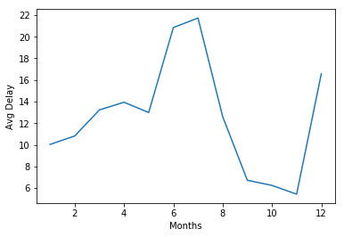

```python
import matplotlib.pyplot as plt
plt.plot(flights_df.groupby(['month'])['dep_delay'].mean())
plt.xlabel('Months')
plt.ylabel('Avg Delay')
plt.show()
```

Summers and festivities like christmas has maximum delays. This shows high delays during vacations specifically.

(d) On average, how do departure delays vary over the course of a day?

```python
flights_df[flights_df['dep_delay']>0].groupby(['hour'])['dep_delay'].mean().sort_values(ascending=False)
```

```
hour
3.0     304.727273
2.0     239.921875
1.0     207.049327
0.0     128.642452
23.0    125.344743
22.0     92.465274
24.0     64.862069
21.0     64.210371
20.0     54.294921
19.0     44.520623
18.0     43.505234
17.0     35.912961
16.0     33.224913
11.0     31.883025
12.0     29.784933
14.0     29.296095
13.0     28.628948
10.0     27.960072
15.0     27.906983
9.0      26.300290
8.0      19.484653
7.0      17.932435
6.0      11.272904
5.0       6.592391
Name: dep_delay, dtype: float64
```

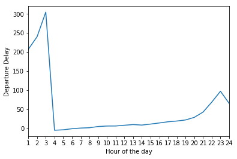

```python
plt.plot(flights_df.groupby(['hour'])['dep_delay'].mean())
plt.xlim(1,24)
plt.xlabel('Hour of the day')
plt.ylabel('Departure Delay')
plt.xticks(range(1,25))
plt.show()
```

Flights depart earlier than scheduled starting at 4 am and there are no delays until 6 am. However, departure delays increase after that and are significantly hight post 12 AM uptil 3 AM.

## Question 3

Which flight departing NYC in 2013 flew the fastest?

```python
flights_df['fastest'] = flights_df.distance/flights_df['air_time']
print(flights_df.sort_values(by='fastest',ascending=False).head(1))
```

```
        Unnamed: 0  year  month  day  dep_time  dep_delay  arr_time  \
216447      216448  2013      5   25    1709.0        9.0    1923.0

        arr_delay carrier tailnum  flight origin dest  air_time  distance  \
216447      -14.0      DL  N666DN    1499    LGA  ATL      65.0       762

        hour  minute       date    fastest
216447  17.0     9.0 2013-05-25  11.723077
```

N666DN, a Delta Airlines Flight No 1499 flew the fastest from LGA to ATL on 25 May 2013.

## Question 4

Which flights (i.e. carrier + flight + dest) happen every day? Where do they fly to?

```python
a = flights_df.groupby(['carrier','flight','dest']).count()
a.sort_values(by="year",ascending=False)
a = a[a['year']==365]
print(type(a))
print(a.iloc[:,0])
```

```
<class 'pandas.core.frame.DataFrame'>
carrier  flight  dest
AA       59      SFO     365
         119     LAX     365
         181     LAX     365
         1357    SJU     365
         1611    MIA     365
B6       219     CLT     365
         359     BUR     365
         371     FLL     365
         431     SRQ     365
         703     SJU     365
         1783    MCO     365
DL       2159    MCO     365
         2391    TPA     365
EV       5712    IAD     365
UA       15      HNL     365
VX       251     LAS     365
         407     LAX     365
         413     LAX     365
Name: Unnamed: 0, dtype: int64
```

AA (59,119,181,1357,1611) to SFO,LAX,LAX,SJU and MIA respectively B6 (219,359,371,431,703,1783) to CLT,BUR,FLL,SRQ,SJU,MCO respectively DL 2159,2391 to MCO and TPA respectively EV 5712 to IAD and UA 15 to HNL VX 251,407 and 413 to LAS and LAX fly out every day of the year.

## Question 5

Develop one research question you can address using the nycflights2013 dataset. Provide two visualizations to support your exploration of this question. Discuss what you find.

Which airport has the best facilities which cause less number of delays with most number of flights flying out? Further, which careers are the best to travel?

```python
best_airport = flights_df.groupby('origin')['dep_delay','arr_delay','fastest'].mean()
best_airport.sort_values(by ='dep_delay', ascending=False)
best_airport.reset_index(level=0, inplace=True)
```

```
  origin  dep_delay  arr_delay   fastest   count
0    EWR  15.107954   9.107055  6.599225  120835
1    JFK  12.112159   5.551481  6.642058  111279
2    LGA  10.346876   5.783488  6.462414  104662
```

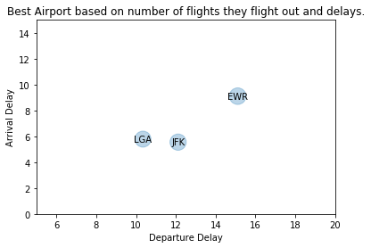

```python
import math
count = flights_df.groupby('origin')['Unnamed: 0'].count()
count = pd.DataFrame(count)
count = count.reset_index(level=0)
best_airport['count'] = count['Unnamed: 0']
print(best_airport)

X = best_airport['dep_delay']
Y = best_airport['arr_delay']
plt.scatter(X, Y,s=list(map(lambda x:x**0.5, list(best_airport['count']))), alpha = 0.3)
plt.rcParams['figure.figsize'] = 17,17
plt.axis([5,20,0,15])
plt.xlabel('Departure Delay')
plt.ylabel('Arrival Delay')
plt.title('Best Airport based on number of flights they flight out and delays.')
a = range(len(best_airport))
for i in a:
    plt.text(X[i],Y[i],best_airport['origin'].loc[i],horizontalalignment='center',verticalalignment='center')

plt.show()
```

```python
best_carrier = flights_df.groupby('carrier')['dep_delay','arr_delay','fastest'].mean()
print(best_carrier)
#print(type(best_carrier))
```

```
         dep_delay  arr_delay   fastest
carrier
9E       16.725769   7.379669  5.757173
AA        8.586016   0.364291  6.957879
AS        5.804775  -9.930889  7.394648
B6       13.022522   9.457973  6.666191
DL        9.264505   1.644341  6.974380
EV       19.955390  15.796431  6.049060
F9       20.215543  21.920705  7.086202
FL       18.726075  20.115906  6.572635
HA        4.900585  -6.915205  8.005962
MQ       10.552041  10.774733  6.140047
OO       12.586207  11.931034  6.105335
UA       12.106073   3.558011  7.014730
US        3.782418   2.129595  5.698995
VX       12.869421   1.764464  7.436249
WN       17.711744   9.649120  6.675533
YV       18.996330  15.556985  5.532833
```

```python
best_carrier.reset_index(level=0, inplace=True)
print(best_carrier)
#plt.bar(best_carrier['carrier'],best_carrier['dep_delay'])
```

```
   carrier  dep_delay  arr_delay   fastest
0       9E  16.725769   7.379669  5.757173
1       AA   8.586016   0.364291  6.957879
2       AS   5.804775  -9.930889  7.394648
3       B6  13.022522   9.457973  6.666191
4       DL   9.264505   1.644341  6.974380
5       EV  19.955390  15.796431  6.049060
6       F9  20.215543  21.920705  7.086202
7       FL  18.726075  20.115906  6.572635
8       HA   4.900585  -6.915205  8.005962
9       MQ  10.552041  10.774733  6.140047
10      OO  12.586207  11.931034  6.105335
11      UA  12.106073   3.558011  7.014730
12      US   3.782418   2.129595  5.698995
13      VX  12.869421   1.764464  7.436249
14      WN  17.711744   9.649120  6.675533
15      YV  18.996330  15.556985  5.532833
```

```python
count_of_carriers = flights_df.groupby('carrier').count()
count_of_carriers = count_of_carriers['Unnamed: 0']
count_of_carriers = pd.DataFrame(count_of_carriers)
count_of_carriers.reset_index(level=0,inplace=True)

best_carrier['count']=count_of_carriers['Unnamed: 0']
print(best_carrier)
```

```
   carrier  dep_delay  arr_delay   fastest  count
0       9E  16.725769   7.379669  5.757173  18460
1       AA   8.586016   0.364291  6.957879  32729
2       AS   5.804775  -9.930889  7.394648    714
3       B6  13.022522   9.457973  6.666191  54635
4       DL   9.264505   1.644341  6.974380  48110
5       EV  19.955390  15.796431  6.049060  54173
6       F9  20.215543  21.920705  7.086202    685
7       FL  18.726075  20.115906  6.572635   3260
8       HA   4.900585  -6.915205  8.005962    342
9       MQ  10.552041  10.774733  6.140047  26397
10      OO  12.586207  11.931034  6.105335     32
11      UA  12.106073   3.558011  7.014730  58665
12      US   3.782418   2.129595  5.698995  20536
13      VX  12.869421   1.764464  7.436249   5162
14      WN  17.711744   9.649120  6.675533  12275
15      YV  18.996330  15.556985  5.532833    601
```

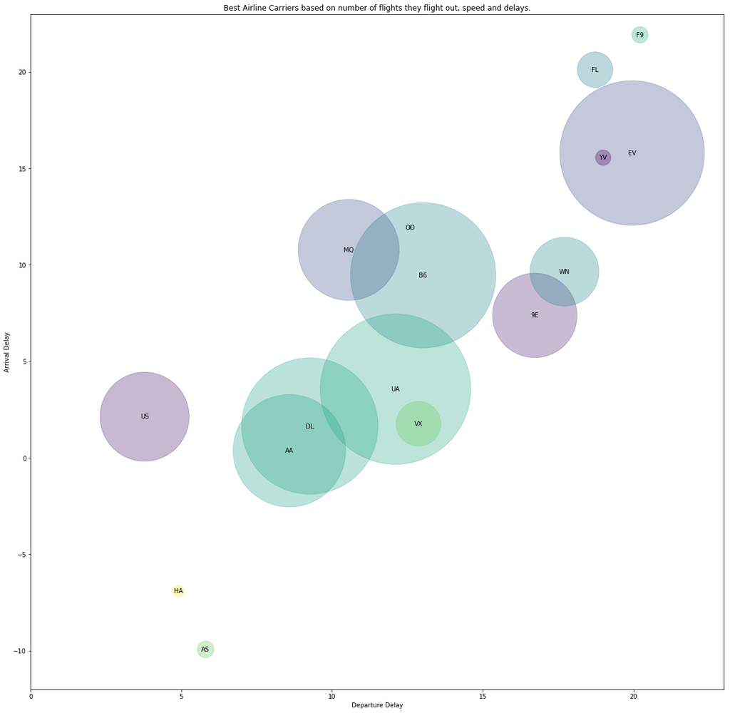

```python
X = best_carrier['dep_delay']
Y = best_carrier['arr_delay']
plt.rcParams['figure.figsize'] = 20, 20
plt.scatter(X, Y, c = best_carrier['fastest'],s=best_carrier['count'], alpha = 0.3)
plt.axis([0,23,-12,23])
plt.xlabel('Departure Delay')
plt.ylabel('Arrival Delay')
plt.title('Best Airline Carriers based on number of flights they flight out, speed and delays.')
a = range(len(best_carrier))
for i in a:
    plt.text(X[i],Y[i],best_carrier['carrier'].loc[i],horizontalalignment='center',verticalalignment='center')

plt.show()
```

```python
best_carrier.sort_values(by='dep_delay').head(1)
```

|  | carrier | dep_delay | arr_delay | fastest | count |
| --- | --- | --- | --- | --- | --- |
| 12 | US | 3.782418 | 2.129595 | 5.698995 | 20536 |

## Question 6

What weather conditions are associated with flight delays leaving NYC? Use graphics to explore.

```python
weather_df=pd.read_csv('weather.csv.bz2')
weather_df.head()
```

|  | Unnamed: 0 | origin | year | month | day | hour | temp | dewp | humid | wind_dir | wind_speed | wind_gust | precip | pressure | visib |
| --- | --- | --- | --- | --- | --- | --- | --- | --- | --- | --- | --- | --- | --- | --- | --- |
| 0 | 1 | EWR | 2013 | 1.0 | 1.0 | 0.0 | 37.04 | 21.92 | 53.97 | 230.0 | 10.35702 | 11.918651 | 0.0 | 1013.9 | 10.0 |
| 1 | 2 | EWR | 2013 | 1.0 | 1.0 | 1.0 | 37.04 | 21.92 | 53.97 | 230.0 | 13.80936 | 15.891535 | 0.0 | 1013.0 | 10.0 |
| 2 | 3 | EWR | 2013 | 1.0 | 1.0 | 2.0 | 37.94 | 21.92 | 52.09 | 230.0 | 12.65858 | 14.567241 | 0.0 | 1012.6 | 10.0 |
| 3 | 4 | EWR | 2013 | 1.0 | 1.0 | 3.0 | 37.94 | 23.00 | 54.51 | 230.0 | 13.80936 | 15.891535 | 0.0 | 1012.7 | 10.0 |
| 4 | 5 | EWR | 2013 | 1.0 | 1.0 | 4.0 | 37.94 | 24.08 | 57.04 | 240.0 | 14.96014 | 17.215830 | 0.0 | 1012.8 | 10.0 |

```python
print(weather_df.origin.unique())
print(weather_df.columns)
print(weather_df[np.isnan(weather_df['month'])])
```

```
['EWR' 'JFK' 'LGA']
Index(['Unnamed: 0', 'origin', 'year', 'month', 'day', 'hour', 'temp', 'dewp',
       'humid', 'wind_dir', 'wind_speed', 'wind_gust', 'precip', 'pressure',
       'visib'],
      dtype='object')
      Unnamed: 0 origin  year  month  day  hour   temp   dewp  humid  \
1630        1631    EWR  2013    NaN  NaN   NaN  44.96  17.96  33.55

      wind_dir  wind_speed  wind_gust  precip  pressure  visib
1630      20.0     3.45234   3.972884     0.0    1025.9   10.0
```

```python
flight_weather_df=pd.merge(flights_df,weather_df,on=['origin','month','day','hour'],how='left')
flight_weather_df.head(20)
```

|  | Unnamed: 0_x | year_x | month | day | dep_time | dep_delay | arr_time | arr_delay | carrier | tailnum | ... | year_y | temp | dewp | humid | wind_dir | wind_speed | wind_gust | precip | pressure | visib |
| --- | --- | --- | --- | --- | --- | --- | --- | --- | --- | --- | --- | --- | --- | --- | --- | --- | --- | --- | --- | --- | --- |
| 0 | 1 | 2013 | 1 | 1 | 517.0 | 2.0 | 830.0 | 11.0 | UA | N14228 | ... | NaN | NaN | NaN | NaN | NaN | NaN | NaN | NaN | NaN | NaN |
| 1 | 2 | 2013 | 1 | 1 | 533.0 | 4.0 | 850.0 | 20.0 | UA | N24211 | ... | NaN | NaN | NaN | NaN | NaN | NaN | NaN | NaN | NaN | NaN |
| 2 | 3 | 2013 | 1 | 1 | 542.0 | 2.0 | 923.0 | 33.0 | AA | N619AA | ... | NaN | NaN | NaN | NaN | NaN | NaN | NaN | NaN | NaN | NaN |
| 3 | 4 | 2013 | 1 | 1 | 544.0 | -1.0 | 1004.0 | -18.0 | B6 | N804JB | ... | NaN | NaN | NaN | NaN | NaN | NaN | NaN | NaN | NaN | NaN |
| 4 | 5 | 2013 | 1 | 1 | 554.0 | -6.0 | 812.0 | -25.0 | DL | N668DN | ... | NaN | NaN | NaN | NaN | NaN | NaN | NaN | NaN | NaN | NaN |
| 5 | 6 | 2013 | 1 | 1 | 554.0 | -4.0 | 740.0 | 12.0 | UA | N39463 | ... | NaN | NaN | NaN | NaN | NaN | NaN | NaN | NaN | NaN | NaN |
| 6 | 7 | 2013 | 1 | 1 | 555.0 | -5.0 | 913.0 | 19.0 | B6 | N516JB | ... | NaN | NaN | NaN | NaN | NaN | NaN | NaN | NaN | NaN | NaN |
| 7 | 8 | 2013 | 1 | 1 | 557.0 | -3.0 | 709.0 | -14.0 | EV | N829AS | ... | NaN | NaN | NaN | NaN | NaN | NaN | NaN | NaN | NaN | NaN |
| 8 | 9 | 2013 | 1 | 1 | 557.0 | -3.0 | 838.0 | -8.0 | B6 | N593JB | ... | NaN | NaN | NaN | NaN | NaN | NaN | NaN | NaN | NaN | NaN |
| 9 | 10 | 2013 | 1 | 1 | 558.0 | -2.0 | 753.0 | 8.0 | AA | N3ALAA | ... | NaN | NaN | NaN | NaN | NaN | NaN | NaN | NaN | NaN | NaN |
| 10 | 11 | 2013 | 1 | 1 | 558.0 | -2.0 | 849.0 | -2.0 | B6 | N793JB | ... | NaN | NaN | NaN | NaN | NaN | NaN | NaN | NaN | NaN | NaN |
| 11 | 12 | 2013 | 1 | 1 | 558.0 | -2.0 | 853.0 | -3.0 | B6 | N657JB | ... | NaN | NaN | NaN | NaN | NaN | NaN | NaN | NaN | NaN | NaN |
| 12 | 13 | 2013 | 1 | 1 | 558.0 | -2.0 | 924.0 | 7.0 | UA | N29129 | ... | NaN | NaN | NaN | NaN | NaN | NaN | NaN | NaN | NaN | NaN |
| 13 | 14 | 2013 | 1 | 1 | 558.0 | -2.0 | 923.0 | -14.0 | UA | N53441 | ... | NaN | NaN | NaN | NaN | NaN | NaN | NaN | NaN | NaN | NaN |
| 14 | 15 | 2013 | 1 | 1 | 559.0 | -1.0 | 941.0 | 31.0 | AA | N3DUAA | ... | NaN | NaN | NaN | NaN | NaN | NaN | NaN | NaN | NaN | NaN |
| 15 | 16 | 2013 | 1 | 1 | 559.0 | 0.0 | 702.0 | -4.0 | B6 | N708JB | ... | NaN | NaN | NaN | NaN | NaN | NaN | NaN | NaN | NaN | NaN |
| 16 | 17 | 2013 | 1 | 1 | 559.0 | -1.0 | 854.0 | -8.0 | UA | N76515 | ... | NaN | NaN | NaN | NaN | NaN | NaN | NaN | NaN | NaN | NaN |
| 17 | 18 | 2013 | 1 | 1 | 600.0 | 0.0 | 851.0 | -7.0 | B6 | N595JB | ... | NaN | NaN | NaN | NaN | NaN | NaN | NaN | NaN | NaN | NaN |
| 18 | 19 | 2013 | 1 | 1 | 600.0 | 0.0 | 837.0 | 12.0 | MQ | N542MQ | ... | NaN | NaN | NaN | NaN | NaN | NaN | NaN | NaN | NaN | NaN |
| 19 | 20 | 2013 | 1 | 1 | 601.0 | 1.0 | 844.0 | -6.0 | B6 | N644JB | ... | 2013.0 | 39.02 | 26.06 | 59.37 | 270.0 | 10.35702 | 11.918651 | 0.0 | 1012.0 | 10.0 |

20 rows × 30 columns

```python
flight_weather_df.wind_speed.value_counts(dropna=False)
```

```
NaN            219535
 6.90468        10892
 5.75390        10844
 9.20624        10351
 8.05546        10098
 4.60312         9578
 0.00000         8964
 10.35702        8750
 11.50780        8263
 3.45234         7770
 12.65858        7044
 13.80936        5842
 14.96014        4747
 16.11092        3449
 17.26170        2864
 18.41248        2293
 19.56326        1287
 20.71404        1129
 21.86482         958
 23.01560         532
 24.16638         453
 25.31716         384
 27.61872         274
 26.46794         118
 28.76950          94
 31.07106          69
 29.92028          45
 33.37262          42
 1048.36058        31
 40.27730          23
 34.52340          19
 39.12652          17
 32.22184          17
Name: wind_speed, dtype: int64
```

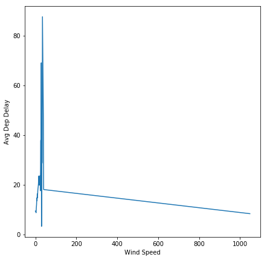

```python
plt.rcParams['figure.figsize'] = 7,7
plt.plot(flight_weather_df.groupby(['wind_speed'])['dep_delay'].mean())
plt.xlabel('Wind Speed')
plt.ylabel('Avg Dep Delay')
plt.show()
```

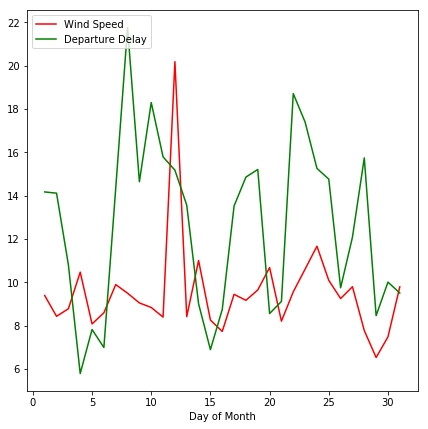

```python
plt.gca().set_color_cycle(['red', 'green'])
plt.plot(flight_weather_df.groupby(['day'])['wind_speed'].mean())
plt.plot(flight_weather_df.groupby(['day'])['dep_delay'].mean())
plt.xlabel('Day of Month')
plt.legend(['Wind Speed', 'Departure Delay'], loc='upper left')
plt.show()
```

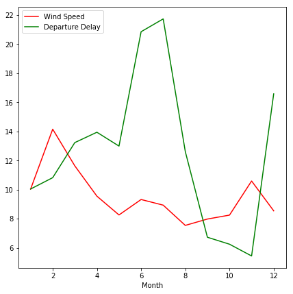

```python
plt.gca().set_color_cycle(['red', 'green'])
plt.plot(flight_weather_df.groupby(['month'])['wind_speed'].mean())
plt.plot(flight_weather_df.groupby(['month'])['dep_delay'].mean())
plt.xlabel('Month')
plt.legend(['Wind Speed', 'Departure Delay'], loc='upper left')
plt.show()
```

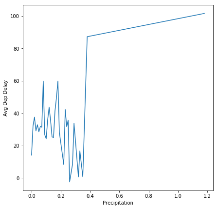

```python
plt.plot(flight_weather_df.groupby(['precip'])['dep_delay'].mean())
plt.xlabel('Precipitation')
plt.ylabel('Avg Dep Delay')
plt.show()
```

Departure delay fluctuates a lot and is general low for precepitation less than 0.4 and is pretty high for precipitation higher than hat.

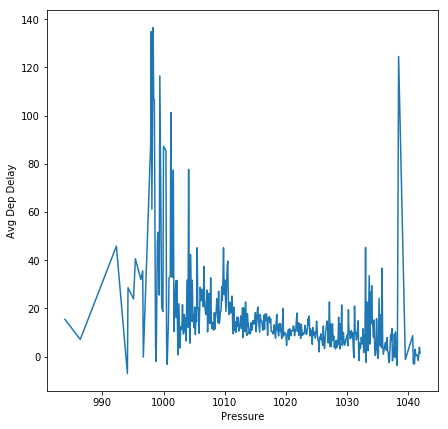

```python
plt.plot(flight_weather_df.groupby(['pressure'])['dep_delay'].mean())
plt.xlabel('Pressure')
plt.ylabel('Avg Dep Delay')
plt.show()
```

Pressure at 1000 and 1040 cause high departure delays.

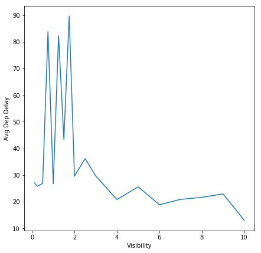

```python
plt.plot(flight_weather_df.groupby(['visib'])['dep_delay'].mean())
plt.xlabel('Visibility')
plt.ylabel('Avg Dep Delay')
plt.show()
```

```python
flight_weather_df.visib.value_counts()
```

```
10.00    96875
9.00      4669
7.00      2280
8.00      2227
6.00      2218
5.00      1682
3.00      1488
2.00      1414
4.00      1241
2.50       754
1.50       645
0.50       603
0.25       539
1.00       415
0.75        96
0.12        50
1.75        37
1.25        18
Name: visib, dtype: int64
```

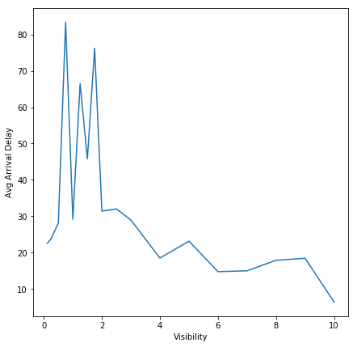

```python
plt.plot(flight_weather_df.groupby(['visib'])['arr_delay'].mean())
plt.xlabel('Visibility')
plt.ylabel('Avg Arrival Delay')
plt.show()
```

Visibility less than 3 caused significant departure and arrival delays. This makes sense because low visibility can cause significant flying difficulties for the pilots.

[figure not shown]

```python
plt.gca().set_color_cycle(['red', 'green'])
plt.plot(flight_weather_df.groupby(['month'])['wind_dir'].mean())
plt.plot(flight_weather_df.groupby(['month'])['dep_delay'].mean())
plt.xlabel('Month')
plt.legend(['Wind Speed', 'Departure Delay'], loc='upper left')
plt.show()
```

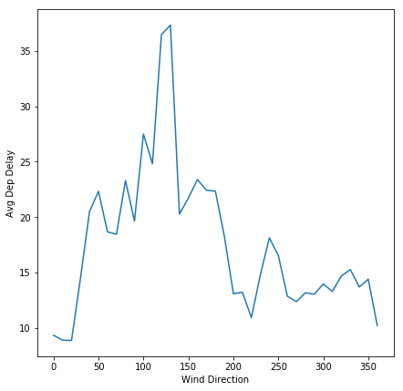

```python
plt.plot(flight_weather_df.groupby(['wind_dir'])['dep_delay'].mean())
plt.xlabel('Wind Direction')
plt.ylabel('Avg Dep Delay')
plt.show()
```

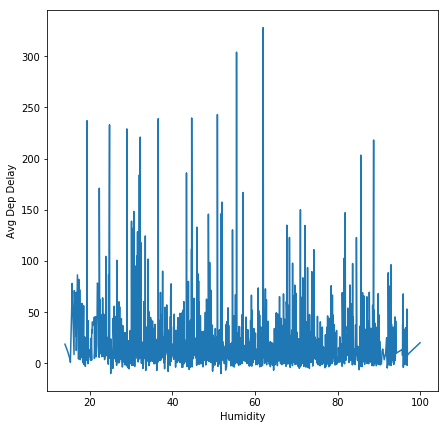

```python
plt.plot(flight_weather_df.groupby(['humid'])['dep_delay'].mean())
plt.xlabel('Humidity')
plt.ylabel('Avg Dep Delay')
plt.show()
```

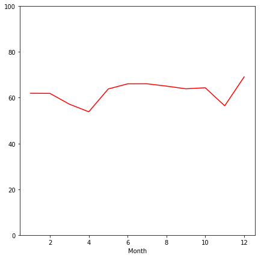

```python
plt.gca().set_color_cycle(['red', 'green'])
plt.plot(flight_weather_df.groupby(['month'])['humid'].mean())

plt.xlabel('Month')
plt.ylim(0,100)

plt.show()
```

Humidity does not really affect departure delay. The coefficient of correlation is also 0.01 which is significantly low.

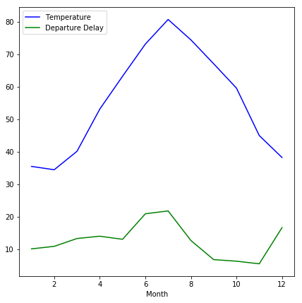

```python
plt.gca().set_color_cycle(['blue', 'green'])
plt.plot(flight_weather_df.groupby(['month'])['temp'].mean())
plt.plot(flight_weather_df.groupby(['month'])['dep_delay'].mean())
plt.xlabel('Month')
plt.legend(['Temperature', 'Departure Delay'], loc='upper left')
plt.show()
```

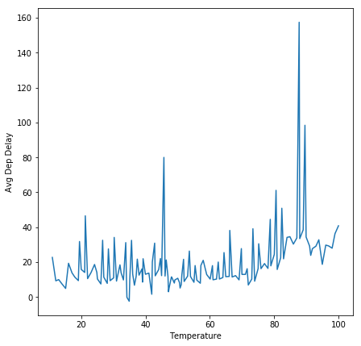

```python
plt.plot(flight_weather_df.groupby(['temp'])['dep_delay'].mean())
plt.xlabel('Temperature')
plt.ylabel('Avg Dep Delay')
plt.show()
```

A temperature of about 90 causes significantly high departure delays.High temperatures are also generally observed during months of June and July which are in fact the months with highest departure delays.

```python
flight_weather_df.corr()
```

|  | Unnamed: 0_x | year_x | dep_time | dep_delay | arr_time | arr_delay | flight | air_time | distance | hour | ... | year_y | temp | dewp | humid | wind_dir | wind_speed | wind_gust | precip | pressure | visib |
| --- | --- | --- | --- | --- | --- | --- | --- | --- | --- | --- | --- | --- | --- | --- | --- | --- | --- | --- | --- | --- | --- |
| Unnamed: 0_x | 1.000000 | NaN | 0.002172 | 0.049713 | -0.024680 | 0.018613 | 0.002676 | -0.032866 | 0.012526 | 0.002236 | ... | NaN | 0.656742 | 0.603927 | 0.047796 | -0.004656 | -0.038486 | -0.038486 | 0.010903 | -0.175798 | 0.109926 |
| year_x | NaN | NaN | NaN | NaN | NaN | NaN | NaN | NaN | NaN | NaN | ... | NaN | NaN | NaN | NaN | NaN | NaN | NaN | NaN | NaN | NaN |
| dep_time | 0.002172 | NaN | 1.000000 | 0.260231 | 0.660779 | 0.232306 | 0.041957 | -0.014619 | -0.013998 | 0.999307 | ... | NaN | 0.210273 | -0.028731 | -0.436612 | 0.113437 | 0.070610 | 0.070610 | 0.006311 | -0.044815 | -0.000111 |
| dep_delay | 0.049713 | NaN | 0.260231 | 1.000000 | 0.028729 | 0.914803 | 0.054734 | -0.022405 | -0.021671 | 0.261786 | ... | NaN | 0.079353 | 0.071246 | 0.013402 | -0.000270 | 0.027402 | 0.027402 | 0.063551 | -0.108860 | -0.112865 |
| arr_time | -0.024680 | NaN | 0.660779 | 0.028729 | 1.000000 | 0.024482 | 0.025042 | 0.054296 | 0.046991 | 0.660232 | ... | NaN | 0.152674 | -0.055869 | -0.390518 | 0.097893 | 0.056455 | 0.056455 | 0.004506 | -0.001776 | 0.011550 |
| arr_delay | 0.018613 | NaN | 0.232306 | 0.914803 | 0.024482 | 1.000000 | 0.072862 | -0.035297 | -0.061868 | 0.233851 | ... | NaN | 0.048765 | 0.050229 | 0.027226 | -0.011018 | 0.025681 | 0.025681 | 0.064447 | -0.117597 | -0.137733 |
| flight | 0.002676 | NaN | 0.041957 | 0.054734 | 0.025042 | 0.072862 | 1.000000 | -0.472838 | -0.484165 | 0.042334 | ... | NaN | 0.004592 | 0.001638 | -0.007368 | 0.007558 | 0.001178 | 0.001178 | -0.011911 | 0.003615 | 0.017510 |
| air_time | -0.032866 | NaN | -0.014619 | -0.022405 | 0.054296 | -0.035297 | -0.472838 | 1.000000 | 0.990650 | -0.013847 | ... | NaN | 0.003027 | 0.004625 | 0.006194 | -0.006158 | -0.000205 | -0.000205 | 0.007783 | -0.003121 | -0.015181 |
| distance | 0.012526 | NaN | -0.013998 | -0.021671 | 0.046991 | -0.061868 | -0.484165 | 0.990650 | 1.000000 | -0.013272 | ... | NaN | 0.052715 | 0.049376 | 0.007631 | -0.012082 | -0.003436 | -0.003436 | 0.007078 | -0.004062 | -0.004266 |
| hour | 0.002236 | NaN | 0.999307 | 0.261786 | 0.660232 | 0.233851 | 0.042334 | -0.013847 | -0.013272 | 1.000000 | ... | NaN | 0.210179 | -0.028789 | -0.436458 | 0.113323 | 0.070490 | 0.070490 | 0.006478 | -0.045011 | -0.000407 |
| minute | -0.001849 | NaN | -0.045081 | -0.058306 | -0.027331 | -0.056303 | -0.012782 | -0.019799 | -0.018595 | -0.082222 | ... | NaN | -0.010850 | 0.003438 | 0.023669 | -0.004051 | -0.001196 | -0.001196 | -0.005029 | 0.008387 | 0.008180 |
| fastest | 0.194342 | NaN | -0.029196 | -0.007766 | 0.001102 | -0.135189 | -0.376182 | 0.614475 | 0.683846 | -0.027838 | ... | NaN | 0.247456 | 0.223559 | 0.011121 | -0.041128 | -0.020001 | -0.020001 | -0.002215 | 0.007133 | 0.044286 |
| Unnamed: 0_y | 0.085280 | NaN | -0.004155 | -0.032978 | -0.000160 | -0.038904 | -0.017192 | 0.051418 | 0.060600 | -0.004295 | ... | NaN | 0.240116 | 0.253354 | 0.077780 | -0.072128 | -0.053154 | -0.053154 | -0.014580 | 0.091260 | 0.048660 |
| year_y | NaN | NaN | NaN | NaN | NaN | NaN | NaN | NaN | NaN | NaN | ... | NaN | NaN | NaN | NaN | NaN | NaN | NaN | NaN | NaN | NaN |
| temp | 0.656742 | NaN | 0.210273 | 0.079353 | 0.152674 | 0.048765 | 0.004592 | 0.003027 | 0.052715 | 0.210179 | ... | NaN | 1.000000 | 0.883316 | 0.013098 | -0.051801 | -0.039933 | -0.039933 | -0.002302 | -0.248876 | 0.070417 |
| dewp | 0.603927 | NaN | -0.028731 | 0.071246 | -0.055869 | 0.050229 | 0.001638 | 0.004625 | 0.049376 | -0.028789 | ... | NaN | 0.883316 | 1.000000 | 0.471723 | -0.192480 | -0.087862 | -0.087862 | 0.069451 | -0.287419 | -0.141921 |
| humid | 0.047796 | NaN | -0.436612 | 0.013402 | -0.390518 | 0.027226 | -0.007368 | 0.006194 | 0.007631 | -0.436458 | ... | NaN | 0.013098 | 0.471723 | 1.000000 | -0.325223 | -0.115404 | -0.115404 | 0.177067 | -0.161484 | -0.512211 |
| wind_dir | -0.004656 | NaN | 0.113437 | -0.000270 | 0.097893 | -0.011018 | 0.007558 | -0.006158 | -0.012082 | 0.113323 | ... | NaN | -0.051801 | -0.192480 | -0.325223 | 1.000000 | 0.140450 | 0.140450 | -0.076497 | -0.212438 | 0.239036 |
| wind_speed | -0.038486 | NaN | 0.070610 | 0.027402 | 0.056455 | 0.025681 | 0.001178 | -0.000205 | -0.003436 | 0.070490 | ... | NaN | -0.039933 | -0.087862 | -0.115404 | 0.140450 | 1.000000 | 1.000000 | -0.004711 | -0.085219 | 0.049409 |
| wind_gust | -0.038486 | NaN | 0.070610 | 0.027402 | 0.056455 | 0.025681 | 0.001178 | -0.000205 | -0.003436 | 0.070490 | ... | NaN | -0.039933 | -0.087862 | -0.115404 | 0.140450 | 1.000000 | 1.000000 | -0.004711 | -0.085219 | 0.049409 |
| precip | 0.010903 | NaN | 0.006311 | 0.063551 | 0.004506 | 0.064447 | -0.011911 | 0.007783 | 0.007078 | 0.006478 | ... | NaN | -0.002302 | 0.069451 | 0.177067 | -0.076497 | -0.004711 | -0.004711 | 1.000000 | -0.088049 | -0.292967 |
| pressure | -0.175798 | NaN | -0.044815 | -0.108860 | -0.001776 | -0.117597 | 0.003615 | -0.003121 | -0.004062 | -0.045011 | ... | NaN | -0.248876 | -0.287419 | -0.161484 | -0.212438 | -0.085219 | -0.085219 | -0.088049 | 1.000000 | 0.108325 |
| visib | 0.109926 | NaN | -0.000111 | -0.112865 | 0.011550 | -0.137733 | 0.017510 | -0.015181 | -0.004266 | -0.000407 | ... | NaN | 0.070417 | -0.141921 | -0.512211 | 0.239036 | 0.049409 | 0.049409 | -0.292967 | 0.108325 | 1.000000 |

23 rows × 23 columns

In sum, temperature, wind speed, visibility, pressure and precipitation tend to affect the delays in flight departures.

```python
import statsmodels.formula.api as sm
model = sm.ols(formula='dep_delay ~ temp', data=flight_weather_df)
result = model.fit()
```

```python
print(result.summary())
```

```
                            OLS Regression Results
==============================================================================
Dep. Variable:              dep_delay   R-squared:                       0.006
Model:                            OLS   Adj. R-squared:                  0.006
Method:                 Least Squares   F-statistic:                     742.9
Date:                Mon, 09 Apr 2018   Prob (F-statistic):          4.49e-163
Time:                        00:13:20   Log-Likelihood:            -6.0233e+05
No. Observations:              117242   AIC:                         1.205e+06
Df Residuals:                  117240   BIC:                         1.205e+06
Df Model:                           1
Covariance Type:            nonrobust
==============================================================================
                 coef    std err          t      P>|t|      [0.025      0.975]
------------------------------------------------------------------------------
Intercept      5.1502      0.385     13.373      0.000       4.395       5.905
temp           0.1787      0.007     27.257      0.000       0.166       0.192
==============================================================================
Omnibus:                   104002.358   Durbin-Watson:                   1.296
Prob(Omnibus):                  0.000   Jarque-Bera (JB):          5082521.630
Skew:                           4.135   Prob(JB):                         0.00
Kurtosis:                      34.177   Cond. No.                         188.
==============================================================================

Warnings:
[1] Standard Errors assume that the covariance matrix of the errors is correctly specified.
```

For every 1 farenheit increase in temperature, the departure delay increases by 0.18 minutes.

```python
model = sm.ols(formula='dep_delay ~ wind_speed', data=flight_weather_df)
result = model.fit()
print(result.summary())
```

```
                            OLS Regression Results
==============================================================================
Dep. Variable:              dep_delay   R-squared:                       0.001
Model:                            OLS   Adj. R-squared:                  0.001
Method:                 Least Squares   F-statistic:                     88.10
Date:                Mon, 09 Apr 2018   Prob (F-statistic):           6.34e-21
Time:                        00:13:20   Log-Likelihood:            -6.0265e+05
No. Observations:              117241   AIC:                         1.205e+06
Df Residuals:                  117239   BIC:                         1.205e+06
Df Model:                           1
Covariance Type:            nonrobust
==============================================================================
                 coef    std err          t      P>|t|      [0.025      0.975]
------------------------------------------------------------------------------
Intercept     14.5153      0.137    106.010      0.000      14.247      14.784
wind_speed     0.0639      0.007      9.386      0.000       0.051       0.077
==============================================================================
Omnibus:                   104078.245   Durbin-Watson:                   1.289
Prob(Omnibus):                  0.000   Jarque-Bera (JB):          5032258.749
Skew:                           4.145   Prob(JB):                         0.00
Kurtosis:                      34.007   Cond. No.                         22.8
==============================================================================

Warnings:
[1] Standard Errors assume that the covariance matrix of the errors is correctly specified.
```

For every increase in wind speed by one unit, the departure delay increases by 0.06

```python
model = sm.ols(formula='dep_delay ~ visib', data=flight_weather_df)
result = model.fit()
print(result.summary())
```

```
                            OLS Regression Results
==============================================================================
Dep. Variable:              dep_delay   R-squared:                       0.013
Model:                            OLS   Adj. R-squared:                  0.013
Method:                 Least Squares   F-statistic:                     1513.
Date:                Mon, 09 Apr 2018   Prob (F-statistic):               0.00
Time:                        00:13:21   Log-Likelihood:            -6.0199e+05
No. Observations:              117251   AIC:                         1.204e+06
Df Residuals:                  117249   BIC:                         1.204e+06
Df Model:                           1
Covariance Type:            nonrobust
==============================================================================
                 coef    std err          t      P>|t|      [0.025      0.975]
------------------------------------------------------------------------------
Intercept     36.0656      0.552     65.375      0.000      34.984      37.147
visib         -2.2688      0.058    -38.895      0.000      -2.383      -2.154
==============================================================================
Omnibus:                   103822.392   Durbin-Watson:                   1.305
Prob(Omnibus):                  0.000   Jarque-Bera (JB):          5084241.408
Skew:                           4.122   Prob(JB):                         0.00
Kurtosis:                      34.189   Cond. No.                         44.0
==============================================================================

Warnings:
[1] Standard Errors assume that the covariance matrix of the errors is correctly specified.
```

for every 1 unit increase in visibility the departure delay decreases by 2.2 mins.

```python
model = sm.ols(formula='dep_delay ~ pressure', data=flight_weather_df)
result = model.fit()
print(result.summary())
```

```
                            OLS Regression Results
==============================================================================
Dep. Variable:              dep_delay   R-squared:                       0.012
Model:                            OLS   Adj. R-squared:                  0.012
Method:                 Least Squares   F-statistic:                     1249.
Date:                Mon, 09 Apr 2018   Prob (F-statistic):          4.65e-272
Time:                        00:13:21   Log-Likelihood:            -5.2881e+05
No. Observations:              104183   AIC:                         1.058e+06
Df Residuals:                  104181   BIC:                         1.058e+06
Df Model:                           1
Covariance Type:            nonrobust
==============================================================================
                 coef    std err          t      P>|t|      [0.025      0.975]
------------------------------------------------------------------------------
Intercept    593.9397     16.421     36.169      0.000     561.754     626.125
pressure      -0.5702      0.016    -35.347      0.000      -0.602      -0.539
==============================================================================
Omnibus:                    99017.074   Durbin-Watson:                   1.359
Prob(Omnibus):                  0.000   Jarque-Bera (JB):          7089729.799
Skew:                           4.477   Prob(JB):                         0.00
Kurtosis:                      42.409   Cond. No.                     1.39e+05
==============================================================================

Warnings:
[1] Standard Errors assume that the covariance matrix of the errors is correctly specified.
[2] The condition number is large, 1.39e+05. This might indicate that there are
strong multicollinearity or other numerical problems.
```

for every one unit increase in pressure the departure delay decreses by 0.5

```python
model = sm.ols(formula='dep_delay ~ precip', data=flight_weather_df)
result = model.fit()
print(result.summary())
```

```
                            OLS Regression Results
==============================================================================
Dep. Variable:              dep_delay   R-squared:                       0.004
Model:                            OLS   Adj. R-squared:                  0.004
Method:                 Least Squares   F-statistic:                     475.5
Date:                Mon, 09 Apr 2018   Prob (F-statistic):          3.37e-105
Time:                        00:13:21   Log-Likelihood:            -6.0251e+05
No. Observations:              117251   AIC:                         1.205e+06
Df Residuals:                  117249   BIC:                         1.205e+06
Df Model:                           1
Covariance Type:            nonrobust
==============================================================================
                 coef    std err          t      P>|t|      [0.025      0.975]
------------------------------------------------------------------------------
Intercept     14.7992      0.121    121.936      0.000      14.561      15.037
precip       106.1176      4.867     21.805      0.000      96.579     115.656
==============================================================================
Omnibus:                   104002.654   Durbin-Watson:                   1.293
Prob(Omnibus):                  0.000   Jarque-Bera (JB):          5051901.880
Skew:                           4.137   Prob(JB):                         0.00
Kurtosis:                      34.074   Cond. No.                         40.4
==============================================================================

Warnings:
[1] Standard Errors assume that the covariance matrix of the errors is correctly specified.
```

For every 1 inch increase in precipitation, the avg departure delay is expected to increase by 106 mins.